# Class 07: Assignment

William Mechler

## Study

A study was conducted to determine the effects of alcohol on human reaction times. Fifty-seven individuals were recruited for this study and were randomly allocated into one of three alcohol treatment groups – a **control** where the subjects remain sober during the entire study, a **moderate** group were the subject is supplied alcohol but is limited in such a way that their blood alcohol content remains under the legal limit to drive (BAC of 0.08) and a group that received a **high** amount of alcohol to which their BAC may exceed the legal limit for driving. Each subject was trained on a video game system and their reaction time (in milliseconds) to a visual stimulus was recorded at 7 time points 30 minutes apart (labeled T0=0, T1=30, T2=60 and so on). At time point T0, all subjects were sober and those in one of the alcohol consumption groups began drinking after the first measured reaction time (controlled within the specifications outlined). It is also of interest to the researcher if a subjects age influences reaction time (namely, is reaction time different for those in the 20s versus 30s).

The task for today is to do a complete analysis for this study and dig into the effects that alcohol, age and time have on mean reaction times.

### Data input and wrangling

First read in the data and peek at the first 6 rows:

```r
alcohol <- read.csv("alcoholReaction.csv")
head(alcohol)
```

```
##   Subject Age Alcohol    T0    T1    T2    T3    T4    T5    T6
## 1       1  24 Control 255.3 254.8 256.4 255.1 257.0 256.1 257.0
## 2       2  34 Control 250.1 249.2 249.0 248.0 248.0 248.9 248.1
## 3       3  31 Control 248.2 247.1 246.9 246.7 246.0 246.0 247.0
## 4       4  24 Control 253.9 253.8 254.9 254.1 253.2 254.1 255.0
## 5       5  38 Control 250.0 251.0 250.0 249.9 248.8 249.1 249.9
## 6       6  38 Control 246.0 248.0 247.0 248.1 248.1 246.9 244.0
```

Note the following:

- The `Age` variable is recorded as an actual numeric age in years, not as categories of 20s or 30s like we want. So, we will need to dichotomize this variable.
- Also note the data is in *wide* format – the reaction times (the response variables) are spread over multiple time-sepcific columns. We need a way to *pivot* these columns into a single column.

So, we need to do some data processing. First, consider the below code:

```r
head(alcohol %>%
       mutate(Age = case_when(Age < 31 ~ "20s",
                              Age %in% 31:40 ~ "30s")))
```

```
##   Subject Age Alcohol    T0    T1    T2    T3    T4    T5    T6
## 1       1 20s Control 255.3 254.8 256.4 255.1 257.0 256.1 257.0
## 2       2 30s Control 250.1 249.2 249.0 248.0 248.0 248.9 248.1
## 3       3 30s Control 248.2 247.1 246.9 246.7 246.0 246.0 247.0
## 4       4 20s Control 253.9 253.8 254.9 254.1 253.2 254.1 255.0
## 5       5 30s Control 250.0 251.0 250.0 249.9 248.8 249.1 249.9
## 6       6 30s Control 246.0 248.0 247.0 248.1 248.1 246.9 244.0
```

`case_when` is essentially a piece-wise comparison. When `Age` is less than 31, you overwrite the `Age` variable with `20s`. If `Age` is in the integers from 31 to 40, you replace the value with `30s`. In this example we used both a `<` comparison and the `%in%` statement we’ve seen before just to show multiple functionality.

**ACTIVITY: Save the dichotomized Age variable.**

```r
alcohol <- alcohol %>%
       mutate(Age = case_when(Age < 31 ~ "20s",
                              Age %in% 31:40 ~ "30s"))

head(alcohol)
```

```
##   Subject Age Alcohol    T0    T1    T2    T3    T4    T5    T6
## 1       1 20s Control 255.3 254.8 256.4 255.1 257.0 256.1 257.0
## 2       2 30s Control 250.1 249.2 249.0 248.0 248.0 248.9 248.1
## 3       3 30s Control 248.2 247.1 246.9 246.7 246.0 246.0 247.0
## 4       4 20s Control 253.9 253.8 254.9 254.1 253.2 254.1 255.0
## 5       5 30s Control 250.0 251.0 250.0 249.9 248.8 249.1 249.9
## 6       6 30s Control 246.0 248.0 247.0 248.1 248.1 246.9 244.0
```

So the `Age` variable has now been categorized. Now, we need to convert the data from *wide* to *long* format. We do this with the `pivot_longer()` function included in `tidyverse`.

**ACTIVITY: Convert the data from wide-to-tall format.**

```r
alcohol.long<- alcohol %>%
  pivot_longer(c(T0,T1,T2,T3,T4,T5,T6), names_to="TimeFrame", values_to="ReactionTime")
```

**pivot_longer().** There are essentially three input arguments into the `pivot_longer()` function:

- *First:* a list of all the columns we want to pivot across – in this case, T0, T1, T2, T3, T4, T5, and T6.
- *Second:* `names_to` - creates the name of a *new* variable whose values will correspond to the original names of the pivoted columns
- *Third:* `values_to` - creates and names a *new* variable that will house the values originally stored in the pivoted columns

```r
# peek at the pivoted data structure
# head(alcohol.long, n=12)
head(alcohol.long, n=12)
```

```
## # A tibble: 12 x 5
##    Subject Age   Alcohol TimeFrame ReactionTime
##      <int> <chr> <chr>   <chr>            <dbl>
##  1       1 20s   Control T0                255.
##  2       1 20s   Control T1                255.
##  3       1 20s   Control T2                256.
##  4       1 20s   Control T3                255.
##  5       1 20s   Control T4                257
##  6       1 20s   Control T5                256.
##  7       1 20s   Control T6                257
##  8       2 30s   Control T0                250.
##  9       2 30s   Control T1                249.
## 10       2 30s   Control T2                249
## 11       2 30s   Control T3                248
## 12       2 30s   Control T4                248
```

You will now note the data is now in a **long** format, which is how we need it expressed for the analysis.

Lastly, so that R doesn’t try and treat it as a number, we tell it that the `Subject` variable is a factor (or categorical) variable. We also want to make sure that the factor levels for `Alcohol` are in the order that makes the best sense.

**ACTIVITY: Correct the factor variables.** In the code chunk below, edit the `alcohol.long` dataset so that the `Subject` variable is treated as a factor, and so that the factor levels in the `Alcohol` varaible are in an logical order (Control, Moderate, High).

```r
alcohol.long <- alcohol.long %>%
  mutate(Subject=as.factor(Subject),
         Alcohol=factor(Alcohol, labels=c("Control",
                                          "High",
                                          "Moderate")))

head(alcohol.long)
```

```
## # A tibble: 6 x 5
##   Subject Age   Alcohol TimeFrame ReactionTime
##   <fct>   <chr> <fct>   <chr>            <dbl>
## 1 1       20s   Control T0                255.
## 2 1       20s   Control T1                255.
## 3 1       20s   Control T2                256.
## 4 1       20s   Control T3                255.
## 5 1       20s   Control T4                257
## 6 1       20s   Control T5                256.
```

### Exploratory Data Analysis

There are 2 categories for age, 3 categories for alcohol use and then 7 time points to consider. Essentially $2\times 3\times 7 = 42$ combinations to consider. Rather than look numerically we will consider things graphically.

First we consider a plot of the Reaction times in Time based on Alcohol treatment with Age determining the linetype.

**ACTIVITY: Make a profile plot of all subjects.**

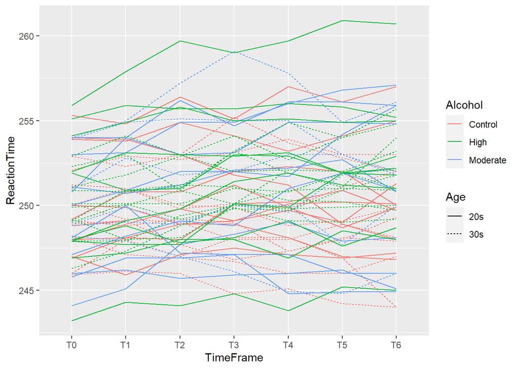

```r
ggplot(alcohol.long) +
    geom_line(aes(x=TimeFrame, y=ReactionTime, color=Alcohol, linetype=Age, group=Subject))
```

With multiple colors and line types, as well as grouping by subject, this plot is crowded with lines. Not only is this plot cluttered, it is hard to determine anything informative.

**ACTIVITY: Facet the plot.** In the code chunk below, edit the plot I made above, but instead facet the plot by `Age`. You should also get rid of the `linetype=` argument. Is the resulting plot improved? Does it still have shortcomings?

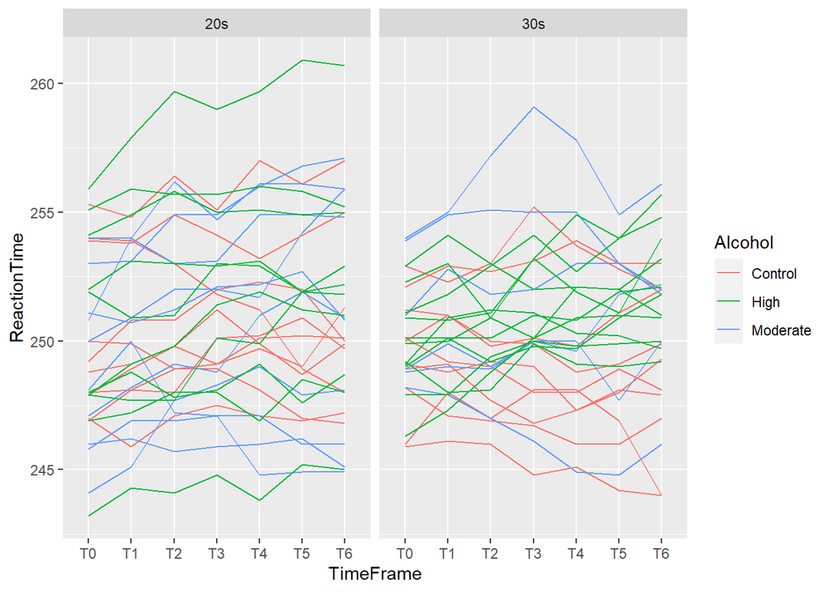

```r
ggplot(alcohol.long) +
    geom_line(aes(x=TimeFrame, y=ReactionTime, color=Alcohol, group=Subject)) +
  facet_wrap(~Age)
```

**ACTIVITY: Plot the means.** To improve the ability to see the factor effects, we can make a plot of the means rather than the raw data, grouping by the `Alcohol` groups while still faceting by `Age`. Write code below to do make such a plot, and comment on what you observe in the resulting plot. We suggest you look back at knitted Markdown from Class 06 for some guidance with code.

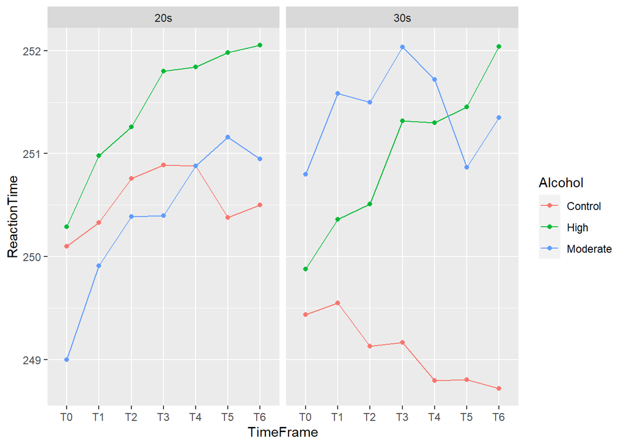

```r
ggplot(alcohol.long, aes(x=TimeFrame, y=ReactionTime, group=Alcohol, color=Alcohol)) +
  stat_summary(fun=mean, geom="line") +
  stat_summary(fun=mean, geom="point") +
  facet_wrap(~Age)
```

**ACTIVITY: Plot the means without faceting.**

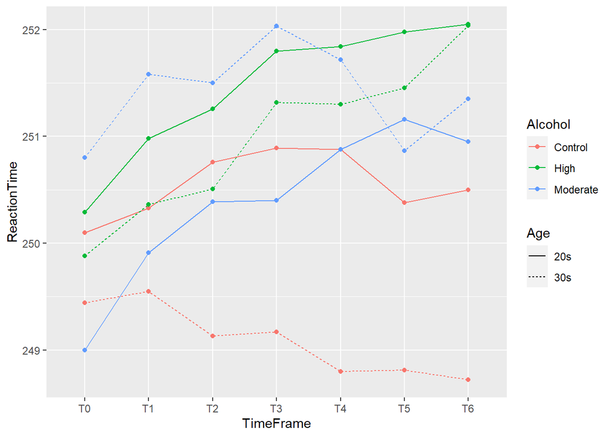

```r
ggplot(alcohol.long, aes(x=TimeFrame, y=ReactionTime, linetype=Age, color=Alcohol, group=interaction(Age, Alcohol))) +
  stat_summary(fun=mean, geom="line") +
  stat_summary(fun=mean, geom="point")
```

**ACTIVITY: Comment on the information provided in any/all the plots provided.**

### Model fitting and analysis

Below is the code to fit the repeated measures ANOVA model to the data:

```r
fit <- aov(ReactionTime ~ Age*Alcohol*TimeFrame + Error(Subject/TimeFrame), data=alcohol.long)
```

*(Remember: you are **not** required to check assumptions using `autoplot` here due to the complexity of repeated measures assumption checking).*

**ACTIVITY: See the ANOVA results.** In the empty code chunk below, write code that allows you to see a summary of the ANOVA results:

```r
summary(fit)
```

```
##
## Error: Subject
##             Df Sum Sq Mean Sq F value Pr(>F)
## Age          1     18   17.72   0.254  0.616
## Alcohol      2    143   71.47   1.026  0.366
## Age:Alcohol  2     93   46.31   0.665  0.519
## Residuals   51   3553   69.66
##
## Error: Subject:TimeFrame
##                        Df Sum Sq Mean Sq F value   Pr(>F)
## TimeFrame               6   50.3   8.386   6.929 6.45e-07 ***
## Age:TimeFrame           6   10.3   1.714   1.416  0.20786
## Alcohol:TimeFrame      12   40.0   3.330   2.752  0.00145 **
## Age:Alcohol:TimeFrame  12   13.8   1.150   0.950  0.49702
## Residuals             306  370.4   1.210
## ---
## Signif. codes:  0 '***' 0.001 '**' 0.01 '*' 0.05 '.' 0.1 ' ' 1
```

**ACTIVITY: Interpret the results.** Using the repeated measures example from Class 07 as a methodological guide, provide a full interpretation of the ANOVA results in problem context. **Perform and interpret any necessary and appropriate follow-up multiple comparisons** using the empty code chunk below (Class 06 material might prove useful as a reference for you).

```r
alcohol.mc <- emmeans(fit, pairwise ~ Alcohol | TimeFrame)
```

```
## Note: re-fitting model with sum-to-zero contrasts
```

```
## NOTE: Results may be misleading due to involvement in interactions
```

```r
contrast(alcohol.mc, "trt.vs.ctrl", ref=1)
```

```
## $emmeans
## TimeFrame = T0:
##  contrast           estimate   SE   df t.ratio p.value
##  High - Control        0.316 1.04 62.1 0.305   0.9216
##  Moderate - Control    0.130 1.13 62.1 0.115   0.9848
##
## TimeFrame = T1:
##  contrast           estimate   SE   df t.ratio p.value
##  High - Control        0.732 1.04 62.1 0.706   0.6971
##  Moderate - Control    0.807 1.13 62.1 0.712   0.6931
##
## TimeFrame = T2:
##  contrast           estimate   SE   df t.ratio p.value
##  High - Control        0.940 1.04 62.1 0.907   0.5677
##  Moderate - Control    1.000 1.13 62.1 0.883   0.5828
##
## TimeFrame = T3:
##  contrast           estimate   SE   df t.ratio p.value
##  High - Control        1.529 1.04 62.1 1.476   0.2537
##  Moderate - Control    1.187 1.13 62.1 1.048   0.4789
##
## TimeFrame = T4:
##  contrast           estimate   SE   df t.ratio p.value
##  High - Control        1.730 1.04 62.1 1.669   0.1798
##  Moderate - Control    1.458 1.13 62.1 1.288   0.3426
##
## TimeFrame = T5:
##  contrast           estimate   SE   df t.ratio p.value
##  High - Control        2.122 1.04 62.1 2.048   0.0836
##  Moderate - Control    1.418 1.13 62.1 1.253   0.3612
##
## TimeFrame = T6:
##  contrast           estimate   SE   df t.ratio p.value
##  High - Control        2.433 1.04 62.1 2.348   0.0420
##  Moderate - Control    1.540 1.13 62.1 1.360   0.3064
##
## Results are averaged over the levels of: Age
## P value adjustment: dunnettx method for 2 tests
##
## $contrasts
```

[output cut: 22 more lines]

```
##  (Control - Moderate) - (Control - High)   0.2717 1.12 62.1  0.242  0.9466
##  (High - Moderate) - (Control - High)      2.0017 1.84 62.1  1.089  0.4542
##
## TimeFrame = T5:
##  contrast                                estimate   SE   df t.ratio p.value
##  (Control - Moderate) - (Control - High)   0.7039 1.12 62.1  0.628  0.7466
##  (High - Moderate) - (Control - High)      2.8262 1.84 62.1  1.537  0.2282
##
## TimeFrame = T6:
##  contrast                                estimate   SE   df t.ratio p.value
##  (Control - Moderate) - (Control - High)   0.8932 1.12 62.1  0.797  0.6388
##  (High - Moderate) - (Control - High)      3.3264 1.84 62.1  1.809  0.1373
##
## Results are averaged over the levels of: Age
## P value adjustment: dunnettx method for 2 tests
```

### Conclusions

**ACTIVITY: Summary plot.**

Build a plot that summarizes the findings of this study and the ANOVA model analysis. That is, provide a single plot that will compliment the story you tell above in the interpretation of the results section and in your overall conclusions below. Consider aggregating the data if necessary, creating a new dataset, etc. Feel free to incorporate other “geoms” that you may know or discover from some internet searching (e.g., `geom_errorbar`).

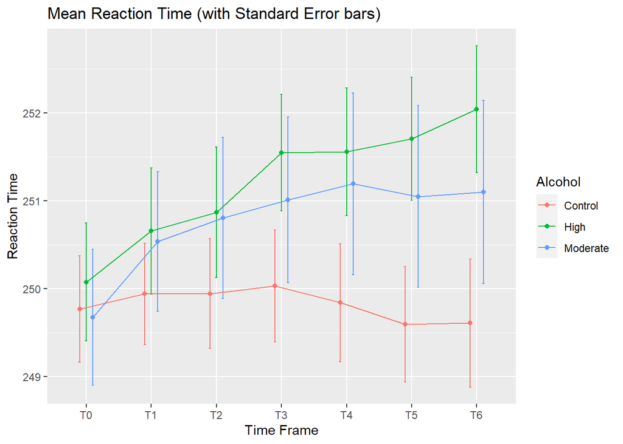

```r
alcohol.summary <- alcohol.long %>%
  group_by(Alcohol, TimeFrame) %>%
  summarise(Mean = mean(ReactionTime),
            SE = sd(ReactionTime)/sqrt(length(ReactionTime)))

ggplot(alcohol.summary, aes(x=TimeFrame, y=Mean, colour=Alcohol)) +
  geom_errorbar(aes(ymin=Mean-SE, ymax=Mean+SE), width=.1, position=position_dodge(0.3)) +
  geom_line(aes(group=Alcohol), position=position_dodge(0.3)) +
  geom_point(position=position_dodge(0.3)) +
  xlab("Time Frame") +
  ylab("Reaction Time") +
  ggtitle("Mean Reaction Time (with Standard Error bars)")
```

**ACTIVITY: State Overall Conclusions of this Study**